# PA1_template

tjstrunk

Sunday, February 15, 2015

First we will load and format the data.

```r
data <- read.csv("activity.csv")
data$date <- as.Date(data$date)
```

Now we give a histogram of the total number of steps taken in a single day (ignoring missing values) and report the mean and median number of steps in a single day

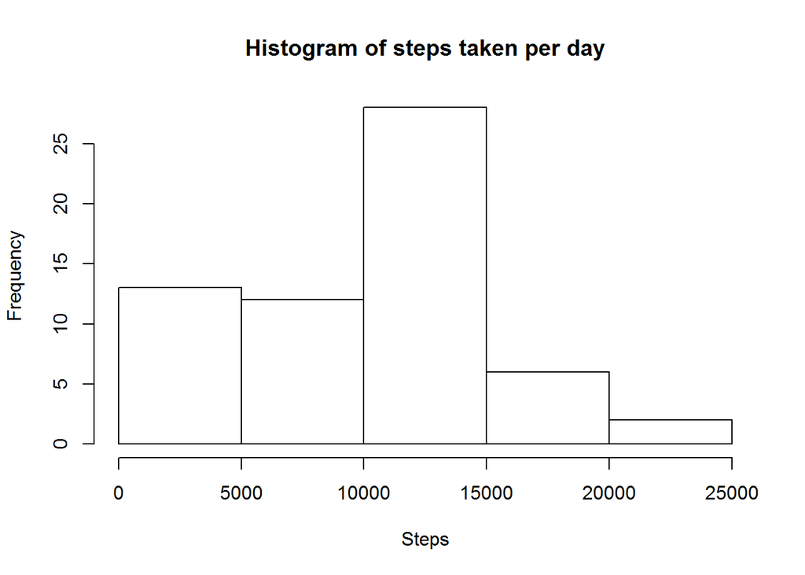

```r
day_sums <- aggregate(data$steps,
                list(data = data$date), sum, na.rm = TRUE)
names(day_sums)[names(day_sums) == "x"] <- "steps"
names(day_sums)[names(day_sums) == "data"] <- "date"
hist(day_sums$steps, xlab = "Steps", main = "Histogram of steps taken per day")
```

```r
mean(day_sums$steps)
```

```
## [1] 9354.23
```

```r
median(day_sums$steps)
```

```
## [1] 10395
```

We might also wonder how many steps are usually taken in a given interval of time, and here we give a plot of the average number of steps taken during a given interval followed by the interval during which participants are taking the most steps (i.e. being most active).

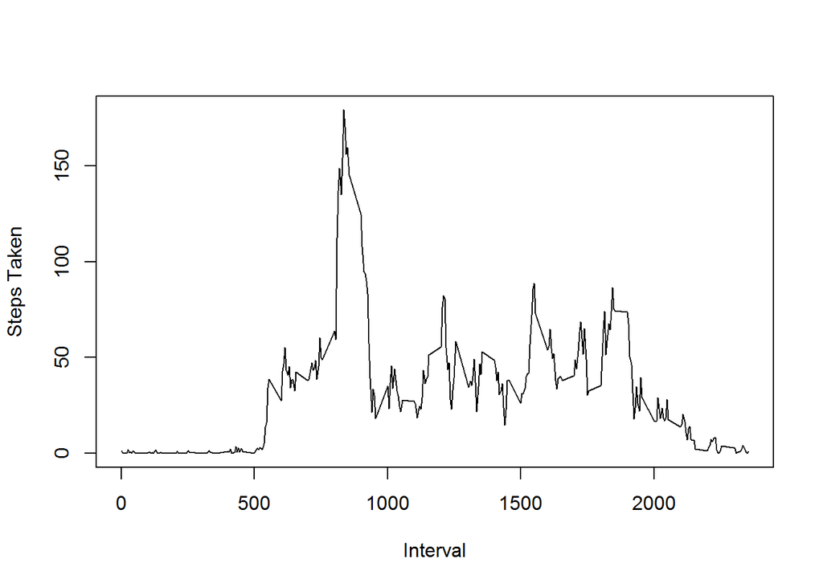

```r
num_days <- length(unique(data$date))
  intval_steps <- aggregate(data$steps,
                    list(interval = data$interval), sum, na.rm = TRUE)
  names(intval_steps)[names(intval_steps) == "x"] <- "steps"
  intval_steps$steps <- intval_steps$steps / num_days
  plot(intval_steps$interval, intval_steps$steps, type = "l", xlab = "Interval", ylab = "Steps Taken")
```

```r
  intval_steps$interval[intval_steps$steps == max(intval_steps$steps)]
```

```
## [1] 835
```

```r
  sum(is.na(data$steps))
```

```
## [1] 2304
```

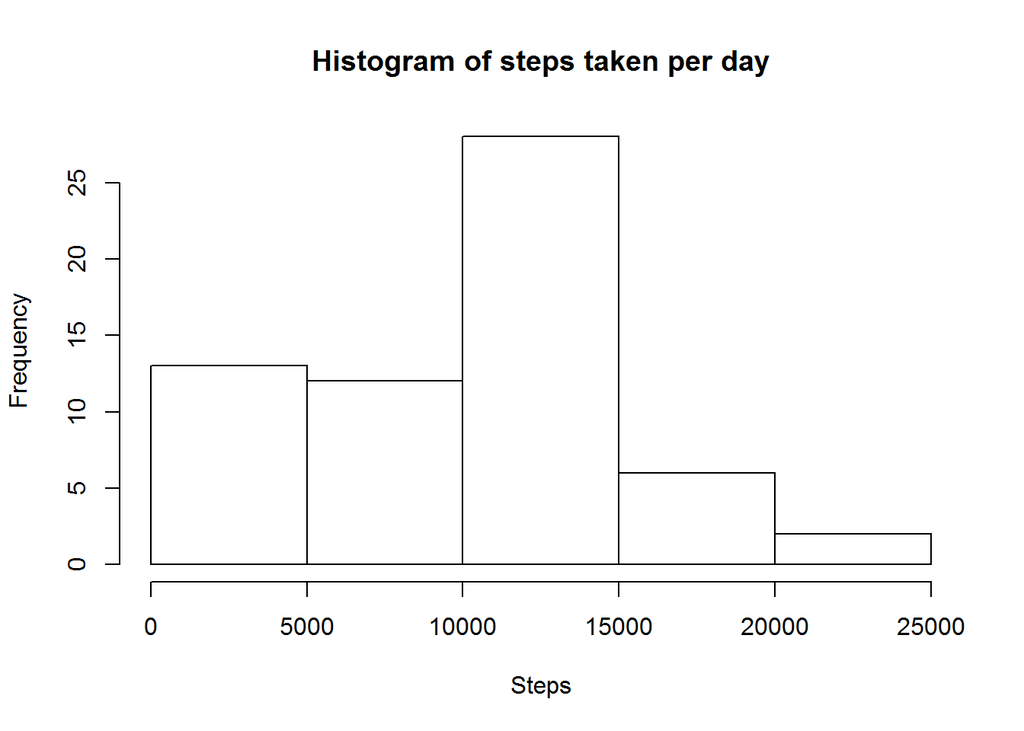

```r
  data$impute <- c(rep(intval_steps$interval, times = 61))
  data$steps[is.na(data$steps)] <- data$impute[is.na(data$steps)]
  hist(day_sums$steps, xlab = "Steps", main = "Histogram of steps taken per day")
```

```r
  mean(day_sums$steps)
```

```
## [1] 9354.23
```

```r
  median(day_sums$steps)
```

```
## [1] 10395
```

Here we use our filled-in data frame to compare the activity of participants on weekdays versus weekends by plotting the average number of steps per interval on a weekend and the average number of steps per interval on a weekday.

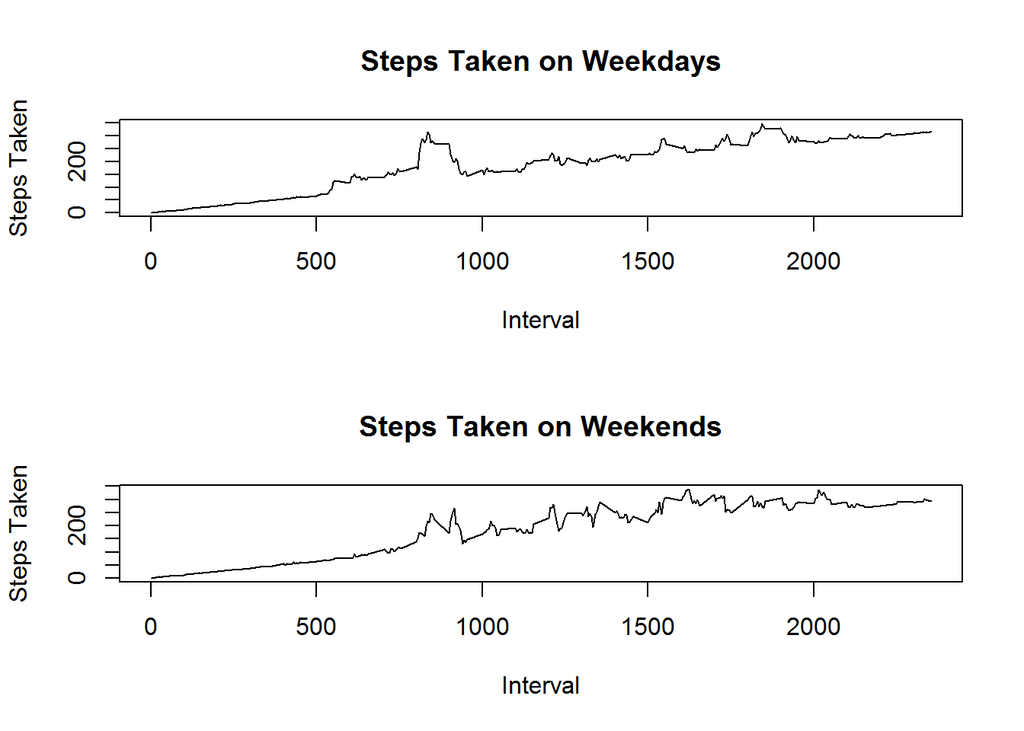

```r
  day_sums <- within(day_sums, {
  day_kind = ifelse(test = weekdays(date) == "Saturday" |
                      weekdays(date) == "Sunday",
                    yes = "weekend", no = "weekday")
  })
  num_weekends <- 0
  for (i in 1:nrow(day_sums)) {
   if(day_sums[i, "day_kind"] == "weekend") {
     num_weekends <- num_weekends + 1
   }
  }
num_weekdays <- nrow(day_sums) - num_weekends
  data <- within(data, {
  day_kind = ifelse(test = weekdays(date) == "Saturday" |
            weekdays(date) == "Sunday",
            yes = "weekend", no = "weekday")
  })
  data$day_kind <- as.factor(data$day_kind)
  weekendata <- subset(data, day_kind == "weekend")
  weekday_data <- subset(data, day_kind == "weekday")
  intval_weekday <- aggregate(weekday_data$steps,
                    list(interval = weekday_data$interval), sum,
                    na.rm = TRUE)
  names(intval_weekday)[names(intval_weekday) == "x"] <- "steps"
  intval_weekday$steps <- intval_weekday$steps / num_weekdays
  intval_weekend <- aggregate(weekendata$steps,
                              list(interval = weekendata$interval), sum,
                              na.rm = TRUE)
  names(intval_weekend)[names(intval_weekend) == "x"] <- "steps"
  intval_weekend$steps <- intval_weekend$steps / num_weekends
  par(mfrow = c(2, 1))
  plot(intval_weekday$interval, intval_weekday$steps, type = "l", xlab = "Interval", ylab = "Steps Taken", main = "Steps Taken on Weekdays")
  plot(intval_weekend$interval, intval_weekend$steps, type = "l", xlab = "Interval", ylab = "Steps Taken", main = "Steps Taken on Weekends")
```